# Внешний курс. Этап №3

Криптография на практике

Сергеев Даниил Олегович

1132246837@rudn.ru

Российский университет дружбы народов

2026-05-11

# Информация

## Докладчик

- Сергеев Даниил Олегович
- Студент
- Направление: Прикладная информатика
- Российский университет дружбы народов
- 1132246837@pfur.ru
- https://github.com/FrigatZero

# Цель работы

- Изучить основы кибербезопасности;
- Понять, как работает Интернет, и какие у него “слабые” места;
- Уяснить, почему `1245YOURNAME` - плохой пароль;
- Научиться отличать шифрование от электронной подписи;
- Узнать, как работают электронные платежи.

# Задание

- Пройти курс;
- Получить сертификат;
- Записать видео по каждому разделу;
- Записать итоговую презентацию по каждому этапу;
- Написать отчёт по прохождению контрольных мероприятий по каждому разделу.

# Ход выполнения лабораторной работы

Приступим к выполнению третьего этапа внешнего курса - Криптографии на практите.

## Введение в криптографию

1. В асимметричных криптографических примитивах каждый участник генерирует себе пару из открытого и секретного ключа, в отличие от симметричной схемы, где используется общий секрет.

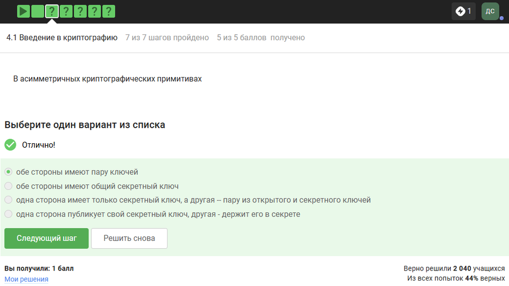

Задание №1. Условие и ответ

## Введение в криптографию

2. Криптографическая хэш-функция выдаёт результат фиксированной длины, стойка к коллизиям и эффективно вычисляется, но не обеспечивает конфиденциальность, так как хэш не шифрует данные.

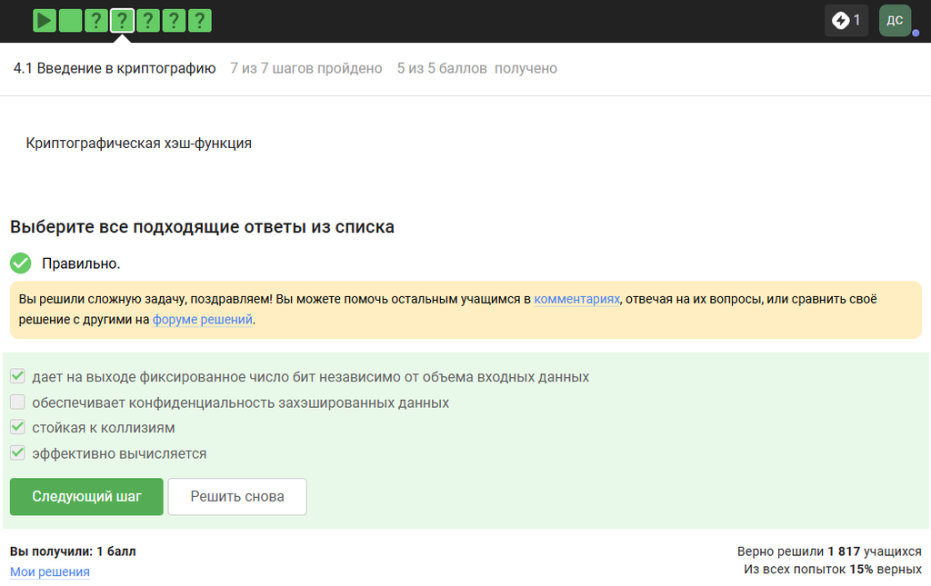

Задание №2. Условие и ответ

## Введение в криптографию

3. К алгоритмам цифровой подписи относятся RSA, ECDSA и ГОСТ Р 34.10-2012. AES это алгоритм шифрования, а SHA2 - хэш-функция.

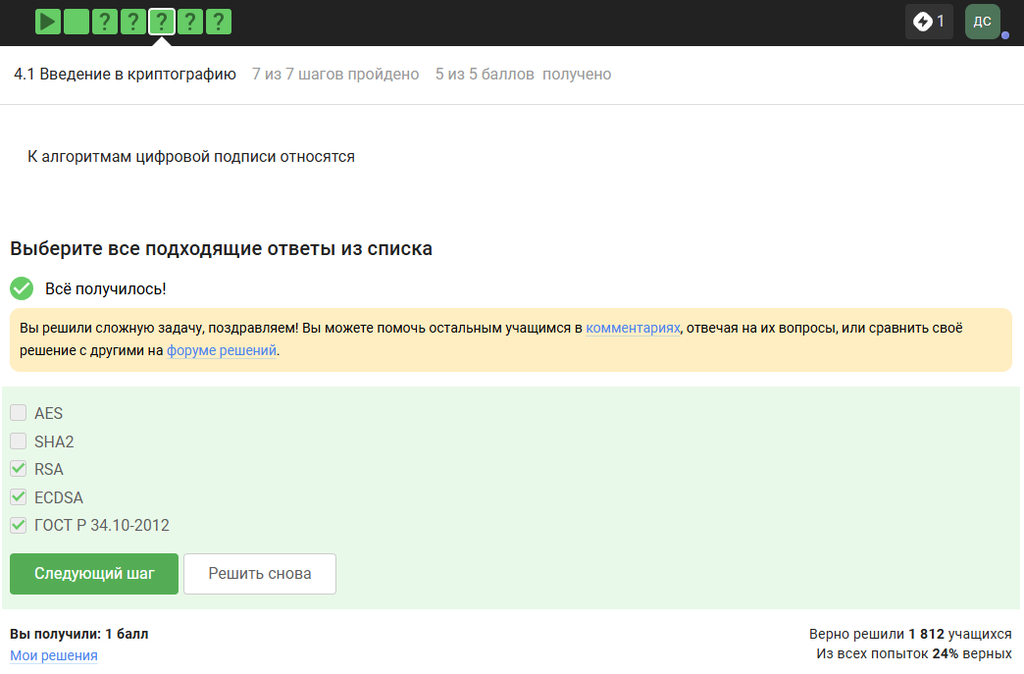

Задание №3. Условие и ответ

## Введение в криптографию

4. Код аутентификации сообщения использует общий секретный ключ для генерации и проверки аутентификационного тега, поэтому относится к симметричным примитивам.

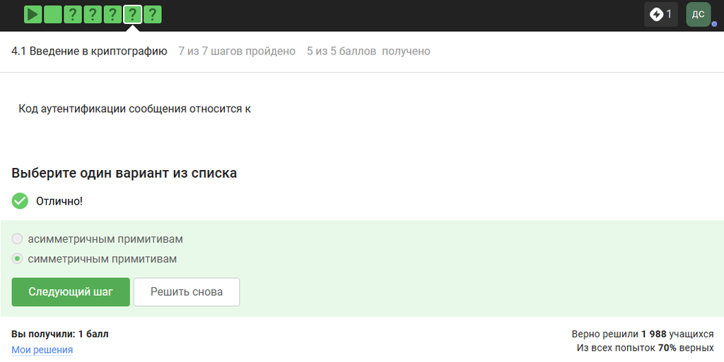

Задание №4. Условие и ответ

## Введение в криптографию

5. Во время обмена ключами Диффи-Хэллмана стороны делятся открытыми параметрами и математически (через остатки) получают одинаковый сеансовый ключ, не раскрывая его по сети.

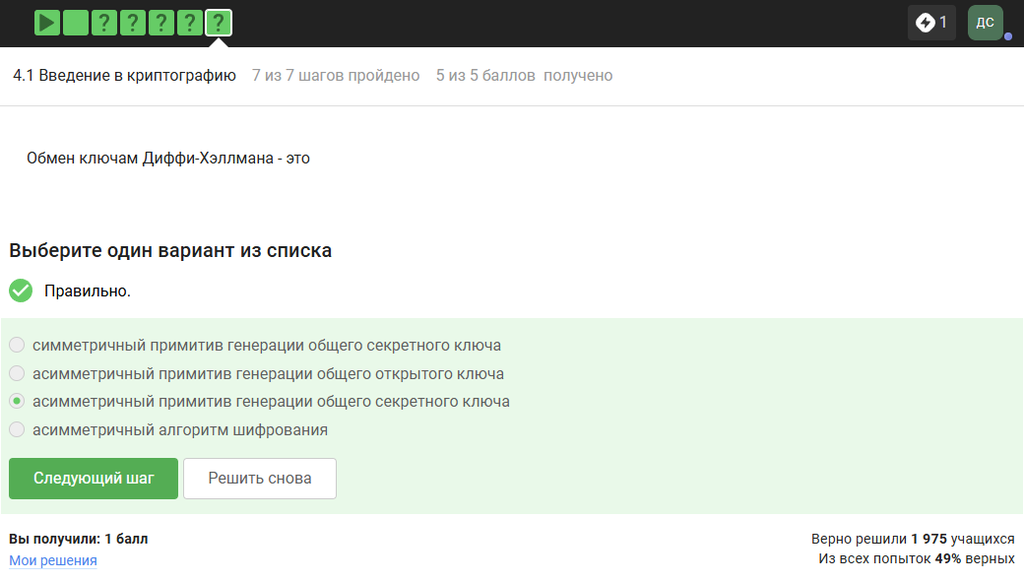

Задание №5. Условие и ответ

## Цифровая подпись

1. Подпись создаётся секретным ключом, а проверяется открытым, что полностью соответствует идее асимметричной криптографии

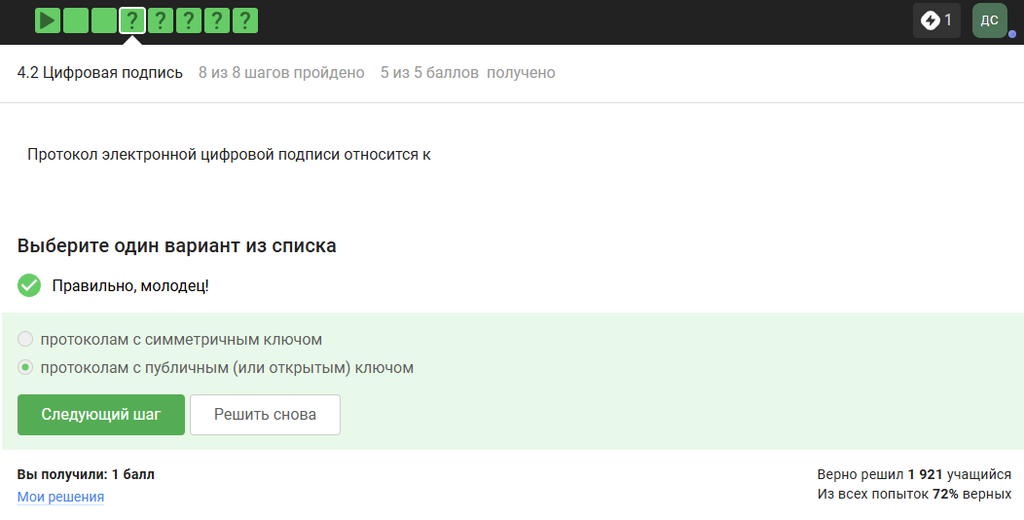

Задание №6. Условие и ответ

## Цифровая подпись

2. Алгоритм проверки сравнивает полученную подпись с результатом применения открытого ключа к хэшу сообщения, поэтому без исходных данных не обойтись.

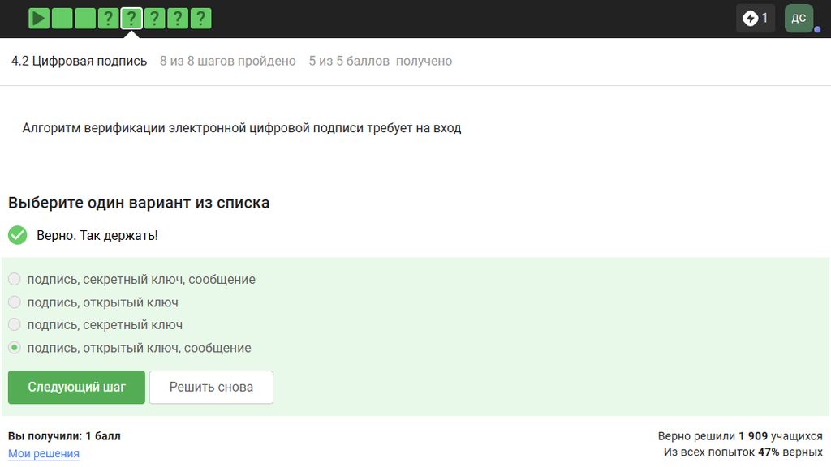

Задание №7. Условие и ответ

## Цифровая подпись

3. Цифровая подпись не обеспечивает конфиденциальность, она лишь подтверждает авторство и целостность, но не скрывает содержимое.

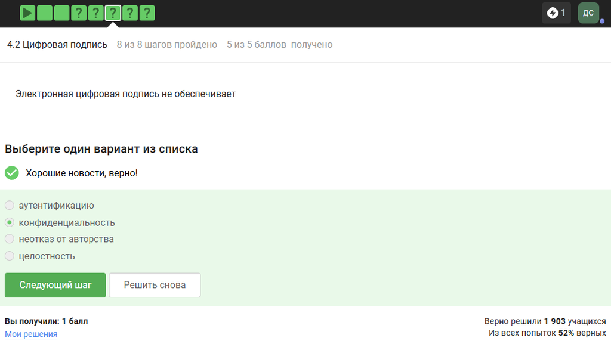

Задание №8. Условие и ответ

## Цифровая подпись

4. Для налоговой отчётности нужна усиленная квалифицированная подпись.

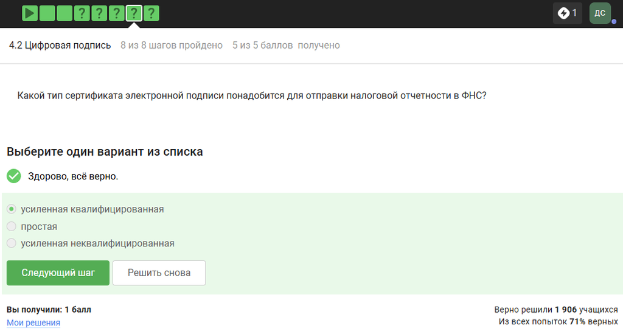

Задание №9. Условие и ответ

## Цифровая подпись

5. Квалифицированный сертификат выдаётся только в аккредитированном удостоверяющем (сертификационном) центре

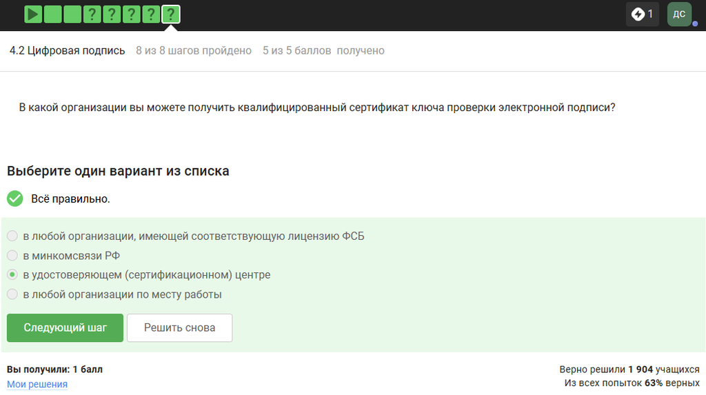

Задание №10. Условие и ответ

## Электронные платежи

1. Bitcoin это криптовалюта, SecurePay это шлюз, а POS-терминал и банкомат это устройства.

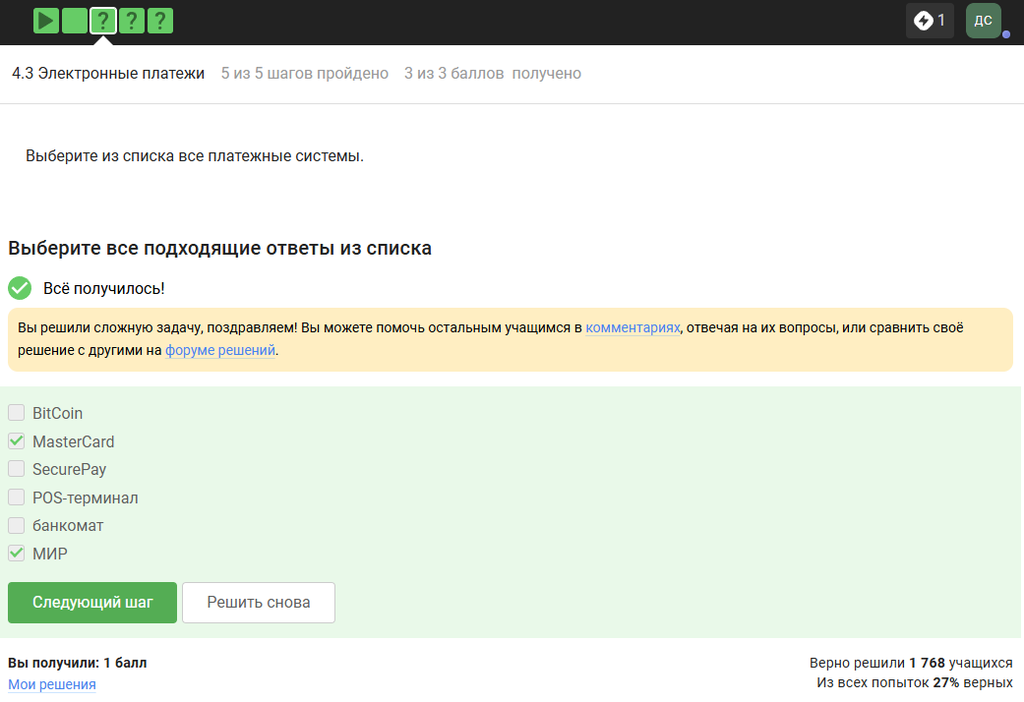

Задание №11. Условие и ответ

## Электронные платежи

2. Капча не является фактором владения или свойством, а пинкод с паролем являются двойным применением одного фактора.

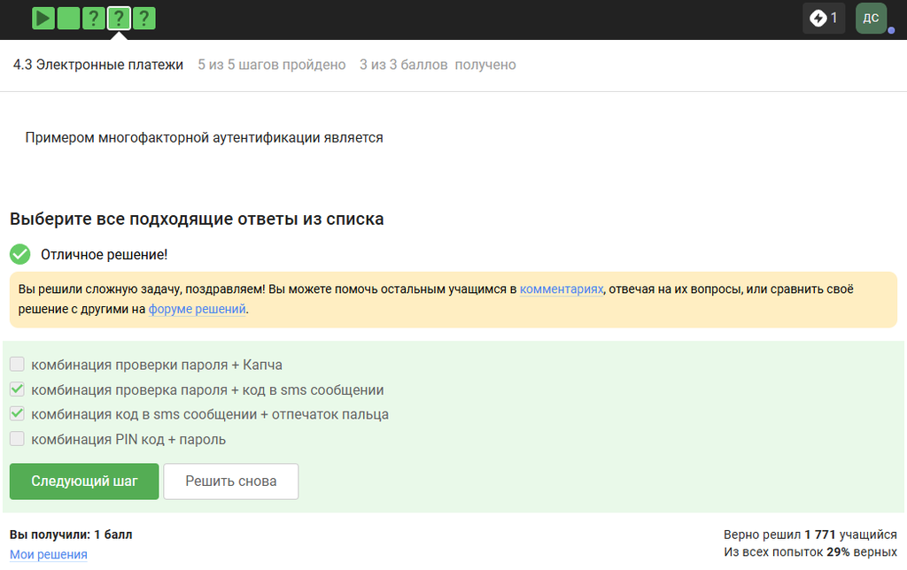

Задание №12. Условие и ответ

## Электронные платежи

3. Банк-эмитент проверяет владельца карты по нескольким факторам перед одобрением транзакции.

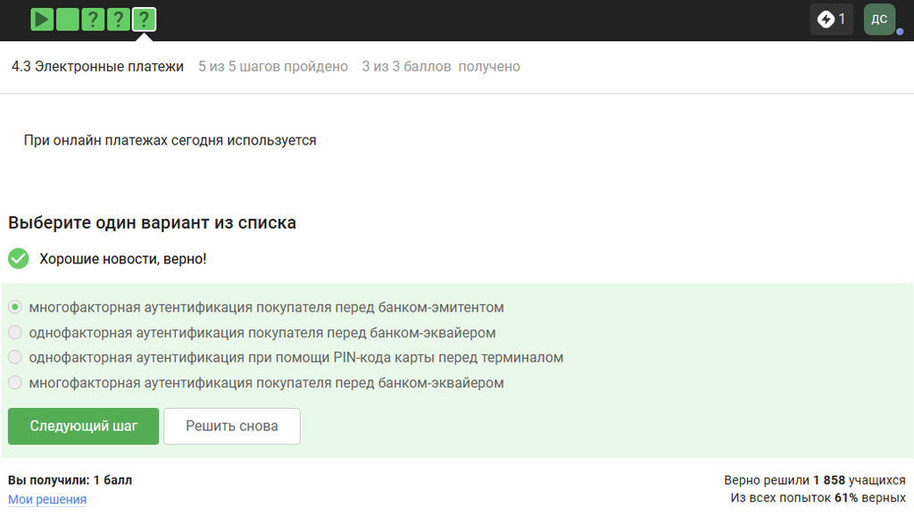

Задание №13. Условие и ответ

## Блокчейн

1. В доказательстве работы используется сложность нахождения прообраза

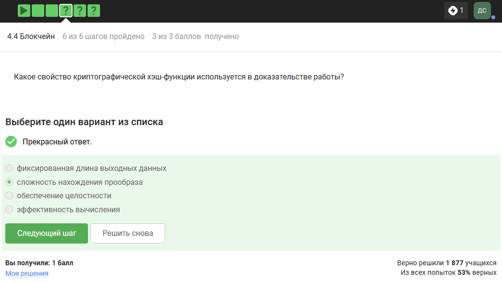

Задание №14. Условие и ответ

## Блокчейн

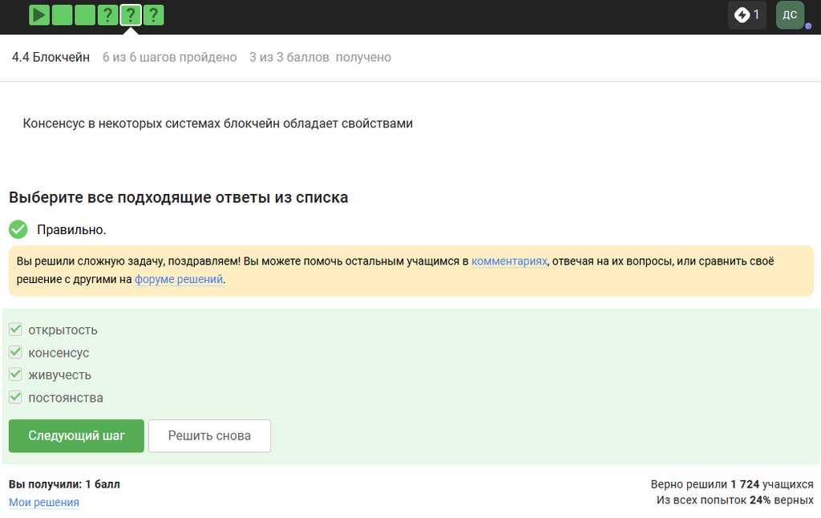

Задание №15. Условие и ответ

## Блокчейн

3. Участники блокчейна хранят секретные ключи для цифровой подписи. Приватный ключ подписи используется для подтверждения транзакций, а шифрование и обмен ключами в обычных блокчейнах напрямую не задействованы.

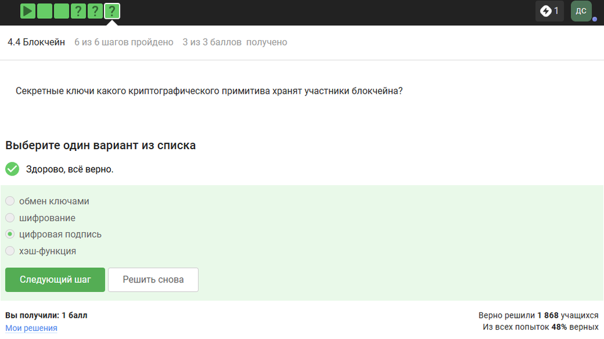

Задание №16. Условие и ответ

# Вывод

В результате выполнения третьего этапа внешнего курса я узнал больше о базовых принципах криптографии, изучил основные термины, условия применения хэш-функций, а также работу блокчейна.

## Вывод

Внешний курс был успешно завершен. Сертификат в нём не выдаётся, поэтому оставим фото о прохождении курса

[figure not shown]

Поздравление за завершение курса

## Вывод

[figure not shown]

Отсутствие сертификата для курса